# Introduction to Classification and Regression Trees (CART)

Daniel Bauer

## Clear the slate and install required packages

```r
rm(list=ls())
#install.packages("earth")
#install.packages("rpart")
#install.packages("tree")
```

As before, we introduce a few helpful functions that make our life below easier.

```r
TPR <- function(y,yhat)  { sum(y==1 & yhat==1) / sum(yhat==1) }
```

# Regression Trees

## Review of Concepts and Maths

### Trees

As we discussed in the lecture, trees successively split the domains of predictors into two areas (greater and smaller), so that the final tree can be thought of as a model with constant predictions in *square partitions* of the feature domain. Hence, in building a tree, we need to address two questions:

1. How to come up with the splits that determine the square partitions?
2. How to come up with the predictions for each of the square partitions?

The second task is straightforward: We simply take the average of all predictions in the current partition.

### Excursion: The Sigmoid Function

In generating our dataset we will use the so-called *sigmoid function*, which will be a key ingredient when we discuss *neural networks*. It has the advantage that depending on the choice of a parameter, it can mimic a highly linear or a highly non-linear relationship:

$$\sigma_{\alpha}(x) = \frac{1}{1+e^{-\alpha\,x}}$$

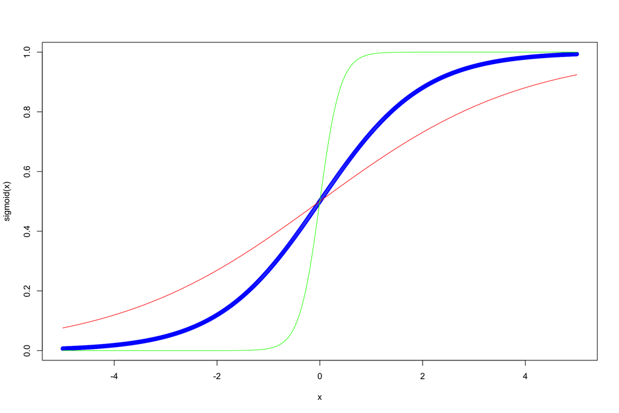

```r
sigmoid = function(x) {
  1 / (1 + exp(-x))
}
x <- seq(-5, 5, 0.01)
plot(x, sigmoid(x), col='blue')
lines(x, sigmoid(0.5 * x), col="red")
lines(x, sigmoid(5 * x), col="green")
```

So we notice that for a small choice of $\alpha$ (red curve), we obtain a relationship that is almost linear (and, indeed, as $\alpha$ becomes smaller and smaller, $\sigma_{\alpha}$ approaches a perfectly linear function). Whereas for a larger choice of $\alpha$ (green curve), we almost obtain a step function (and, indeed, as $\alpha$ becomes larger and larger, $\sigma_{\alpha}$ approaches a step function).

## A Simulated Example with One Predictor

1. Let’s start by generating two datasets based on the sigmoid function with different parameters taken from above.

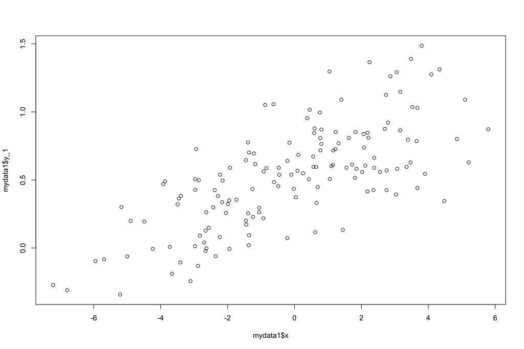

   ```r
   set.seed(3)
   x <- 3 * rnorm(150)
   eps <- 0.25 * rnorm(150)

   y_1 <- sigmoid(0.5 * x) + eps
   y_2 <- sigmoid(5 * x) + eps

   mydata1 <- data.frame(y_1,x)
   mytraindata1 <- mydata1[1:100,]
   mytestdata1 <- mydata1[101:150,]

   plot(mydata1$x,mydata1$y_1)
   ```

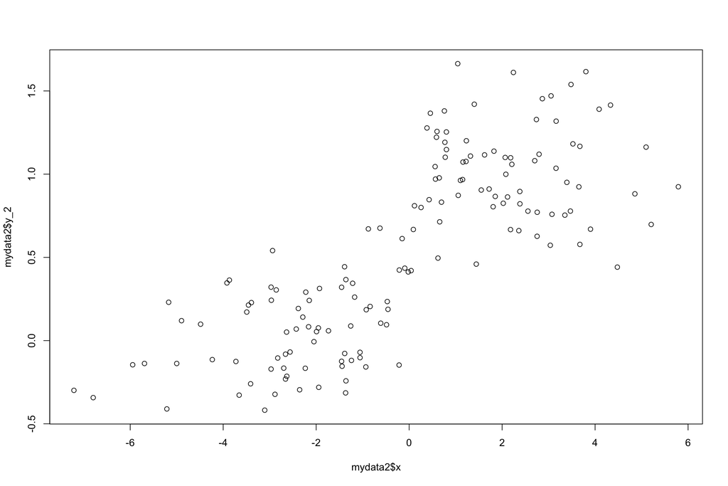

   ```r
   mydata2 <- data.frame(y_2,x)
   mytraindata2 <- mydata2[1:100,]
   mytestdata2 <- mydata2[101:150,]

   plot(mydata2$x,mydata2$y_2)
   ```

2. And, for comparison, let’s fit a linear regression model to both datasets and let’s evaluate the out-of-sample error.

   ```r
   lmfit1 <- lm(y_1 ~ x, mytraindata1)
   yOLShat1 <- predict(lmfit1,mytestdata1)
   OLS_OOS_MSE1 <- sum((mytestdata1$y_1 - yOLShat1)^2)/50
   OLS_OOS_MSE1
   ```

   ```
   [1] 0.06001665
   ```

   ```r
   lmfit2 <- lm(y_2 ~ x, mytraindata2)
   yOLShat2 <- predict(lmfit2,mytestdata2)
   OLS_OOS_MSE2 <- sum((mytestdata2$y_2 - yOLShat2)^2)/50
   OLS_OOS_MSE2
   ```

   ```
   [1] 0.1083534
   ```

3. Let’s fit a tree to the second dataset.

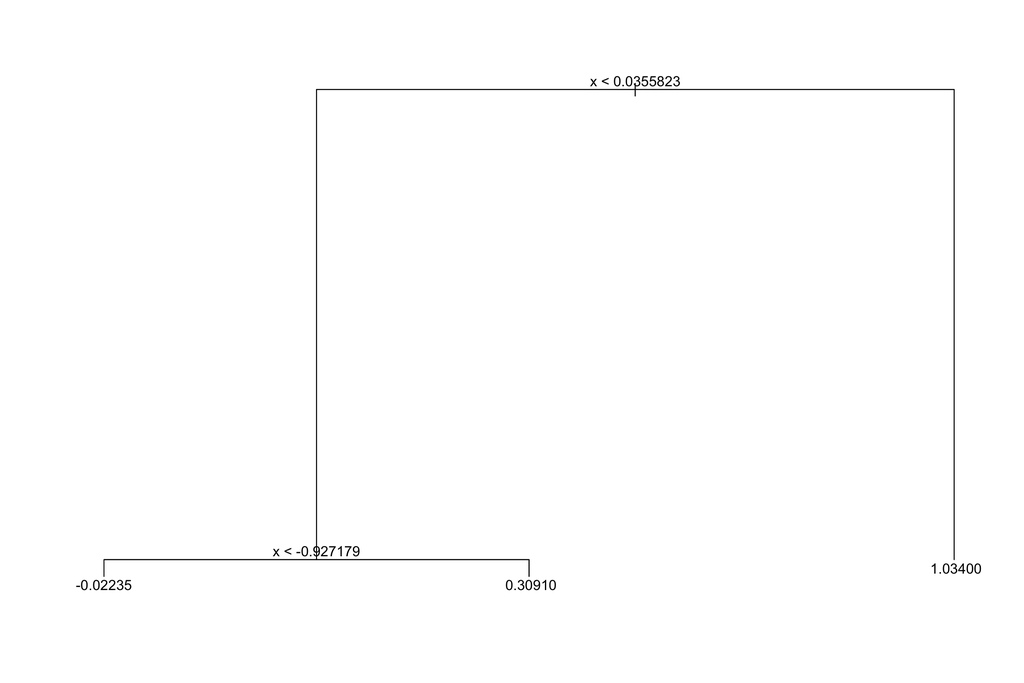

   ```r
   library(tree)
   tree2 <- tree(y_2 ~ x, mytraindata2)
   plot(tree2)
   text(tree2,pretty=0)
   ```

4. Let’s use cross validation to see what size is optimal, and let’s prune accordingly.

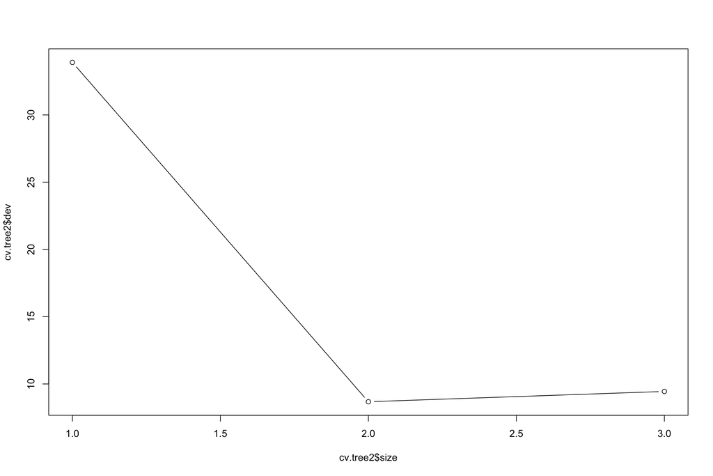

   ```r
   cv.tree2 <- cv.tree(tree2, K = 5)
   plot(cv.tree2$size, cv.tree2$dev, type='b')
   ```

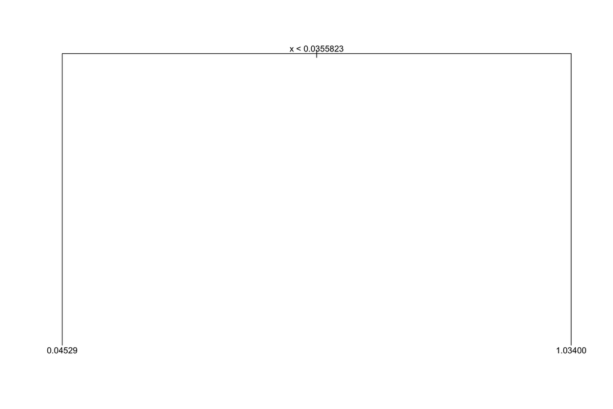

   ```r
   prunetree2 = prune.tree(tree2, best=2)
   plot(prunetree2)
   text(prunetree2, pretty=0)
   ```

   ```r
   ytreehat2 <- predict(prunetree2, newdata = mytestdata2)
   OLS_TREE_MSE2 <- sum((mytestdata2$y_2 - ytreehat2)^2)/50
   OLS_TREE_MSE2
   ```

   ```
   [1] 0.07057412
   ```

5. Let’s redo for the first dataset.

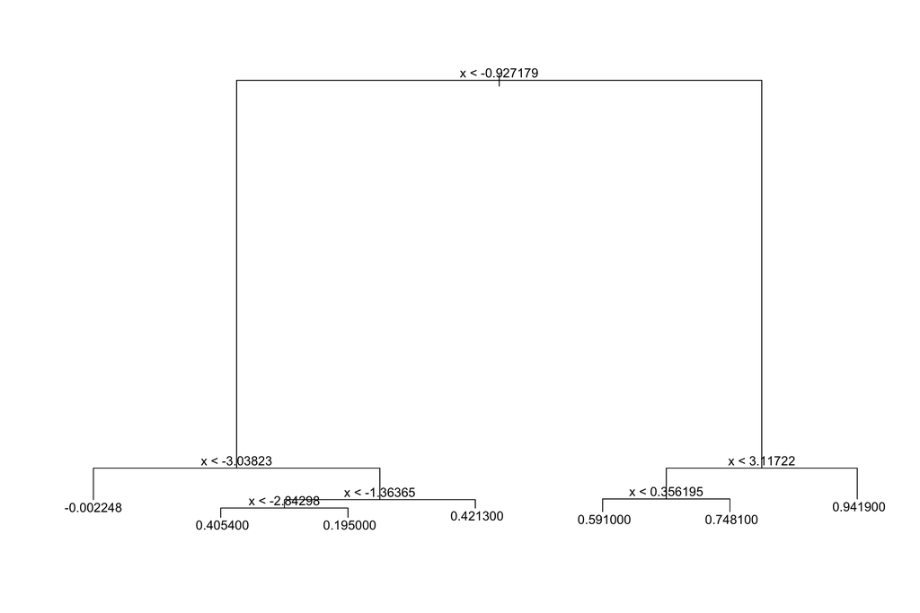

   ```r
   tree1 <- tree(y_1 ~ x, mytraindata1)
   plot(tree1)
   text(tree1, pretty=0)
   ```

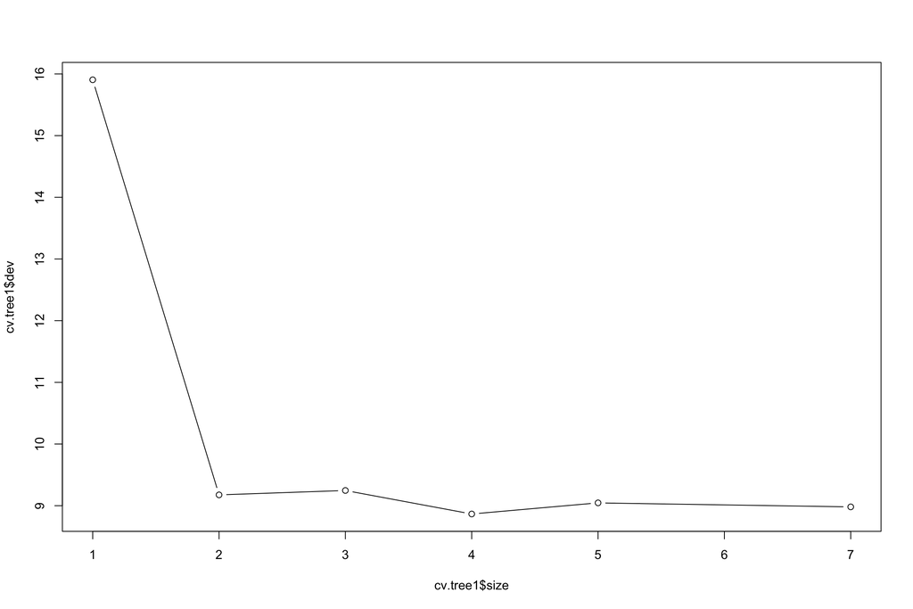

   ```r
   cv.tree1 <- cv.tree(tree1, K = 5)
   plot(cv.tree1$size, cv.tree1$dev, type='b')
   ```

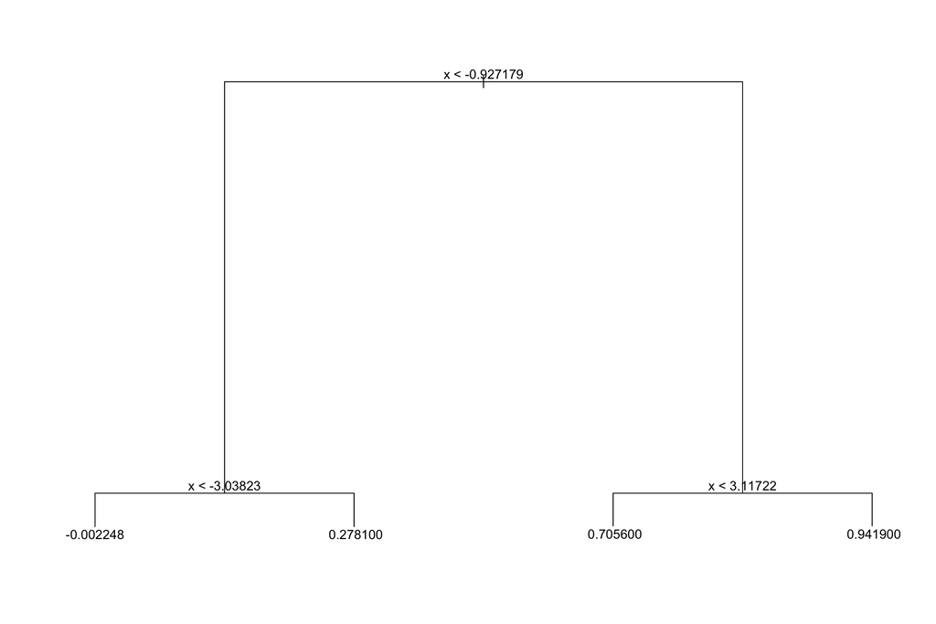

   ```r
   prunetree1 <- prune.tree(tree1, best=4)
   plot(prunetree1)
   text(prunetree1, pretty=0)
   ```

   ```r
   ytreehat1 <- predict(prunetree1, newdata = mytestdata1)
   OLS_TREE_MSE1 <- sum((mytestdata1$y_1 - ytreehat1)^2)/50
   OLS_TREE_MSE1
   ```

   ```
   [1] 0.07369689
   ```

Hence, overall, trees are well-suited for modeling non-linear relationships – which explains their relevance as the foundational structural element for more advanced learners.

## Case Study I: Caravan Insurance Purchases

Let’s go back to the `Caravan` insurance data:

```r
library(ISLR)
data(Caravan)
dat <- Caravan
dat$Purchase <- I(dat$Purchase=="Yes")*1
X <- scale(dat[,1:85])
tst <- 1:1000
X.trn <- X[-tst,]
X.tst <- X[tst,]
Y.trn <- dat[-tst,86]
Y.tst <- dat[tst,86]
train <- dat[-tst,]
test <- dat[tst,]
```

### Classification Tree

Let’s try a classification tree, with the caveat that we have to change the default parameters. The standard value of the so-called complexity parameter `cp` is insufficient to generate sufficient splits, because a split only happens if there is sufficient heterogeneity in the nodes. We set it to 0.001 but we can generate an even larger tree by a lower choice.

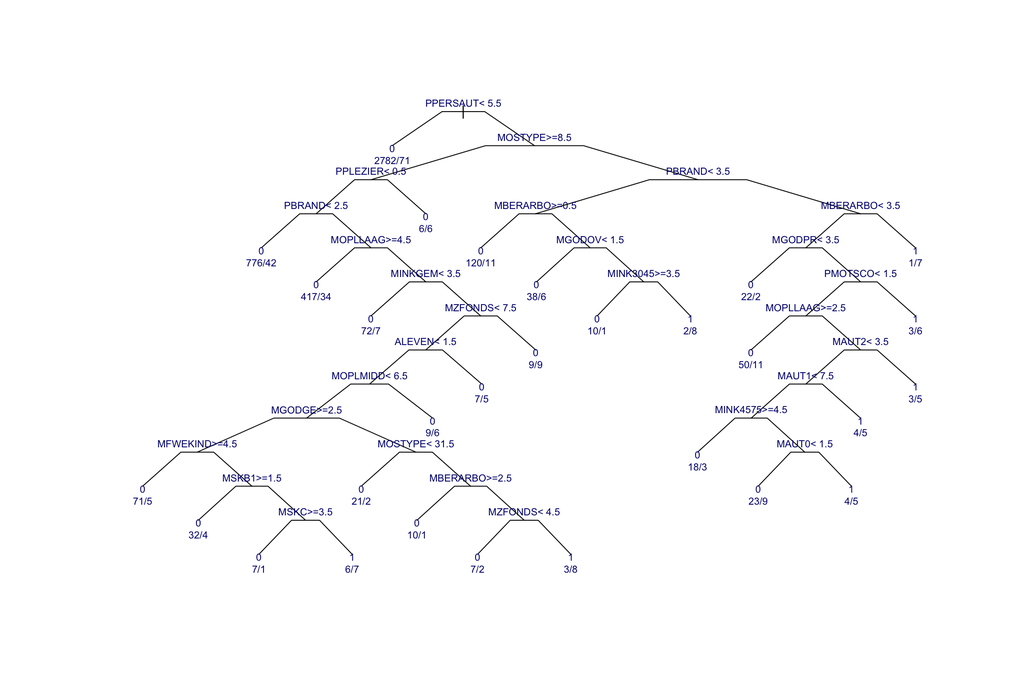

```r
library(rpart)
form1 <- formula(Purchase~.)
t1 <- rpart(form1, data=train, cp=.001, method="class")
plot(t1,uniform=T,compress=T,margin=.05,branch=0.3)
text(t1, cex=.7, col="navy",use.n=TRUE)
```

So an immediate advantage of the tree is its interpretability. It’s immediatly evident how the tree arrives at predictions. We specified a complexity parameter of 0.001, but `rpart` (usually) automatically performs a cross validation. The so-called `cptable` in the fit contains the mean and standard deviation of the errors in the cross-validated prediction. These can be plotted via:

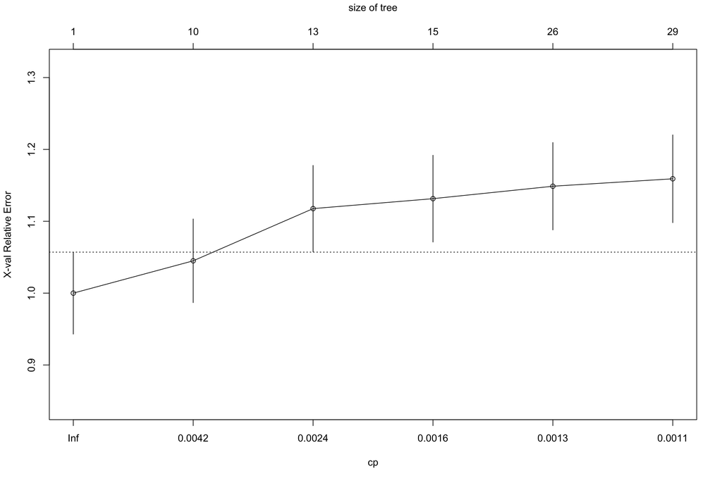

```r
plotcp(t1)
```

```r
CP <- printcp(t1)
```

```
Classification tree:
rpart(formula = form1, data = train, method = "class", cp = 0.001)

Variables actually used in tree construction:
 [1] ALEVEN   MAUT0    MAUT1    MAUT2    MBERARBO MFWEKIND MGODGE   MGODOV
 [9] MGODPR   MINK3045 MINK4575 MINKGEM  MOPLLAAG MOPLMIDD MOSTYPE  MSKB1
[17] MSKC     MZFONDS  PBRAND   PMOTSCO  PPERSAUT PPLEZIER

Root node error: 289/4822 = 0.059934

n= 4822

         CP nsplit rel error xerror     xstd
1 0.0051903      0   1.00000 1.0000 0.057034
2 0.0034602      9   0.94810 1.0450 0.058219
3 0.0017301     12   0.93772 1.1176 0.060069
4 0.0015728     14   0.93426 1.1315 0.060413
5 0.0011534     25   0.91696 1.1488 0.060839
6 0.0010000     28   0.91349 1.1592 0.061093
```

```r
cp <- CP[,1][CP[,2] == 9]
cp
```

```
          2
0.003460208
```

Let’s prune accordingly:

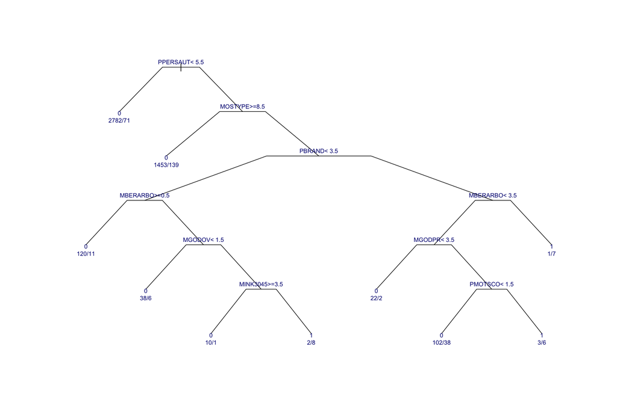

```r
t2 <- prune(t1,cp=cp[1])
plot(t2,uniform=T,compress=T,margin=.05,branch=0.3)
text(t2, cex=.7, col="navy",use.n=TRUE)
```

```r
yhat.t2 <- predict(t2, test, type="prob")[,2]
table(yhat.t2>0.5,Y.tst)
```

```
       Y.tst
          0   1
  FALSE 937  58
  TRUE    4   1
```

```r
TPR(yhat.t2>0.5,Y.tst)
```

```
[1] 0.01694915
```

So at least we are getting one right.

```r
library("pROC")
t2.roc <- roc(Y.tst, yhat.t2, direction="<")
t2.roc
```

```
Call:
roc.default(response = Y.tst, predictor = yhat.t2, direction = "<")

Data: yhat.t2 in 941 controls (Y.tst 0) < 59 cases (Y.tst 1).
Area under the curve: 0.7049
```

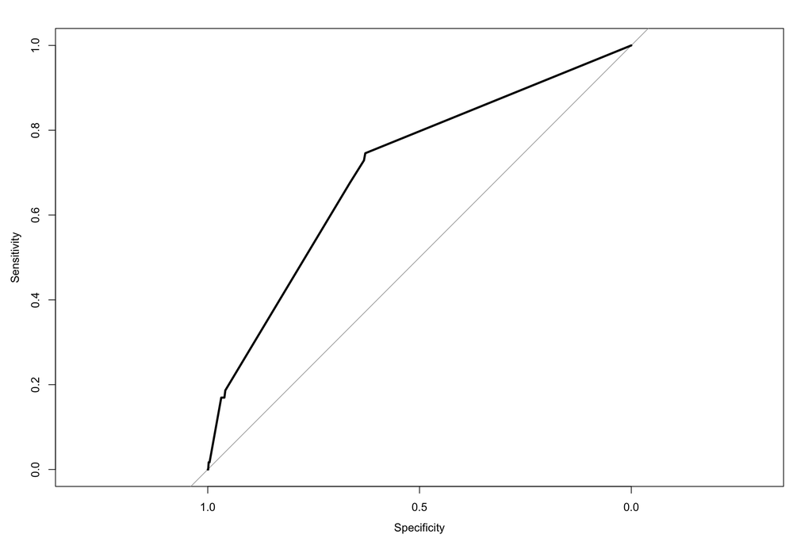

```r
plot(t2.roc, lwd=3)
```

However, the AUC is a little worse relative to our linear models.

## Case Study II: Credit Card Defaults

Let’s go back to our second example:

```r
mydata <- readRDS("my_UCICredit_data.rds")
set.seed(42)
index <- sort(sample(1:nrow(mydata),round(0.75*nrow(mydata))))
train <- mydata[index,]
test  <- mydata[-index,]
```

As a reminder, the AUC for the GAM was 0.7754 and the confusion table for a GLM with 50% cutoff was:

$$\begin{array}{l c c}
& \text{Y.tst} &&\\
\text{FALSE} & 5572 & 1033\\
\text{TRUE} & 272 & 623
\end{array}$$

Let’s fit a classification tree:

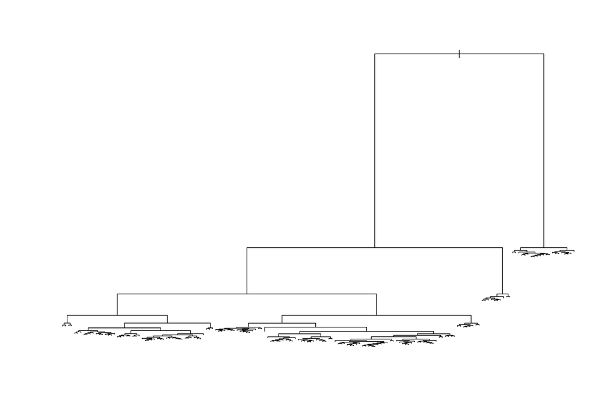

```r
library(tree)
myc <- tree.control(nrow(train),minsize=5, mindev=0.0003)
t1 <- tree(default ~ .,  data=train, control = myc)
plot(t1)
```

```r
summary(t1)
```

```
Classification tree:
tree(formula = default ~ ., data = train, control = myc)
Number of terminal nodes:  168
Residual mean deviance:  0.7973 = 17800 / 22330
Misclassification error rate: 0.1699 = 3822 / 22500
```

```r
cv.t1 <- cv.tree(t1, K = 5)
cv.t1
```

```
$size
  [1] 168 167 166 164 163 162 160 159 158 157 156 155 154 153 151 150 149 147
 [19] 145 144 143 142 141 140 139 138 137 136 134 133 132 131 130 127 126 122
 [37] 121 120 118 117 116 112 111 110 109 108 107 106 105 104 102 101  98  96
 [55]  95  94  91  88  85  81  80  79  78  77  76  75  73  72  70  69  66  65
 [73]  64  61  60  59  58  57  56  55  54  52  49  47  46  45  44  42  38  37
 [91]  36  35  33  32  27  26  25  24  23  22  21  20  19  16  15  14  12  11
[109]   9   7   6   5   4   3   2   1

$dev
  [1] 20201.26 20201.26 20201.26 20201.26 20201.26 20201.26 20201.26 20201.26
  [9] 20201.26 20201.26 20201.26 20201.26 20201.26 20201.26 20201.26 20201.26
 [17] 20201.26 20201.26 20201.26 20201.26 20201.26 20201.26 20201.26 20201.26
 [25] 20201.26 20201.26 20201.26 20201.26 20201.26 20201.26 20201.26 20201.26
 [33] 20201.26 20201.26 20201.26 20201.26 20201.26 20201.26 20201.26 20201.26
```

[output cut: 38 more lines]

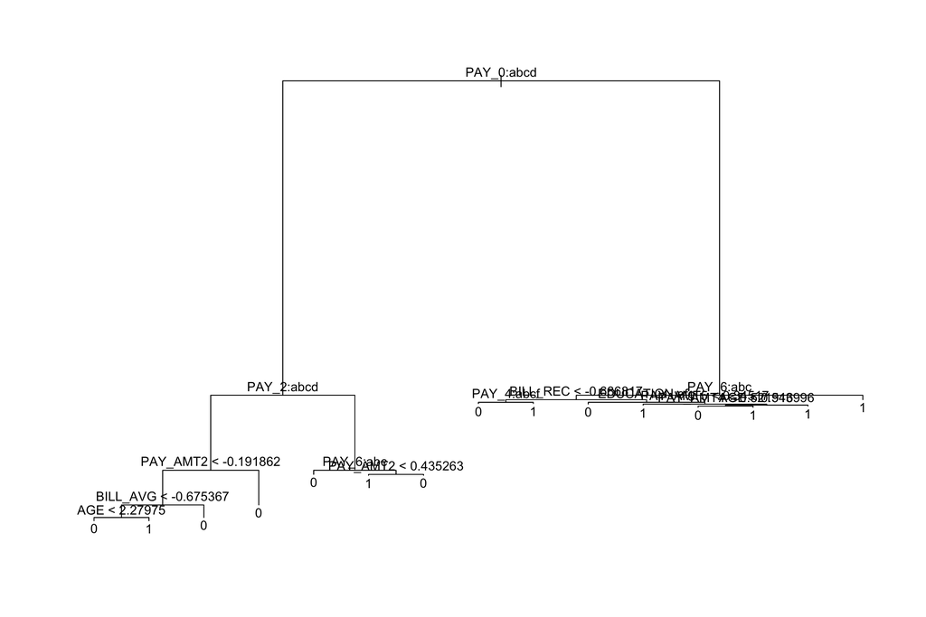

```r
t2 <- prune.misclass(t1, best = 15)
plot(t2)
text(t2)
```

As a side note, the choice of 15 is somewhat arbitrary given the cross-validation results, in part due to the low number of defaults (just classifying as “no” is not a bad learner from a misclassification perspective). If we have a clear sense of what the costs of different misclassifications are, we can prune accounting for that. More precisely, `prune.misclass(t1, best = 15, loss = matrix(c(0,c1,c2,0), byrow=TRUE, nrow=2))` would prune assuming cost parameters for `c1` and `c2` for different misclassifications. Of course, this is also relevant in the previous case study.

Let’s check the predictions:

```r
yhat.t2 <- predict(t2, newdata = test)

table(yhat.t2[,2]>0.5,test$default)
```

```
           0    1
  FALSE 5560 1030
  TRUE   284  626
```

```r
library("pROC")
t2.roc <- roc(test$default, yhat.t2[,2], direction="<")
t2.roc
```

```
Call:
roc.default(response = test$default, predictor = yhat.t2[, 2],     direction = "<")

Data: yhat.t2[, 2] in 5844 controls (test$default 0) < 1656 cases (test$default 1).
Area under the curve: 0.7423
```

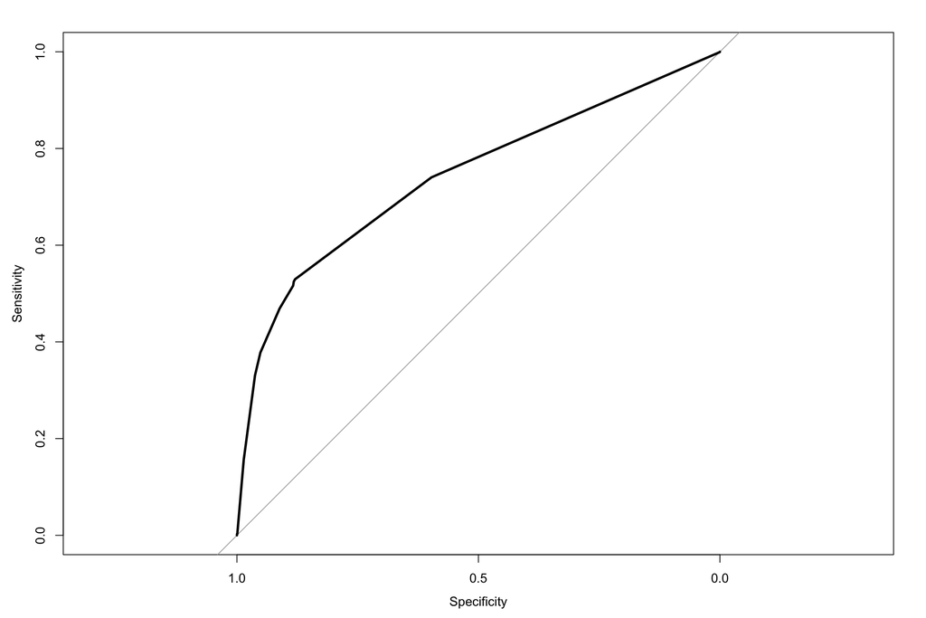

```r
plot(t2.roc, lwd=3)
```

So not really an improvement relative to our GAM model…

So to summarize:

- CARTS have several nice properties. They deliver understandable predictions (tree form) and they map non-linear relationships well.
- However, in the context of our applications, they were not very competitive.